# Direct-capture barnyard ambient overdispersion is doublet-driven

Reproducing CLEANSER’s Figure 3B from raw counts, exposing the doublets, and re-drawing it Poisson

Author

sceptre3 gRNA-assignment investigation

Published

July 2, 2026

```r
suppressPackageStartupMessages({
  library(Matrix)
  library(ggplot2)
  library(knitr)
})
theme_set(theme_bw(base_size = 12))
# All data paths are RELATIVE to this .qmd's folder, so it renders in place.
REPRO <- "external/repro_work"
# small helper for inline numbers
fmt <- function(x, d = 2) formatC(x, format = "f", digits = d, big.mark = ",")
```

# 1 What this note settles

CLEANSER (Liu et al. 2025) models per-guide ambient gRNA counts with a **Negative Binomial (NB)** and shows, in its **Figure 3B**, that in the **direct-capture** barnyard experiment the ground-truth ambient is strongly **overdispersed** (variance $\gg$ mean), whereas in the **CROP-seq** experiment it sits on the Poisson line. fishash / geomux instead assume a **Poisson / hypergeometric** ambient null. These look contradictory.

This note shows, **entirely from the raw barnyard counts and with every number produced by executable code**, that:

1. **CLEANSER’s Fig 3B reproduces** — direct-capture per-guide ambient really is overdispersed (median var/mean $\approx 10$); CROP-seq really is Poisson (var/mean $\approx 1$).
2. **The overdispersion is doublet-driven.** A right tail of cells carry a whole wrong-species cell’s worth of gRNA UMIs (co-encapsulated doublets), and the **top 1% of cells account for $\approx 98.5\%$ of the excess variance.**
3. **Removing gRNA-channel doublets collapses Fig 3B onto the Poisson line** — the per-guide variance-vs-mean cloud pulls back onto $\mathrm{var}=\mathrm{mean}$, and a **direct, bootstrap-calibrated goodness-of-fit test** (§Part 4) cannot distinguish the de-doubleted direct-capture ambient from $\mathrm{Poisson}(a_g\,d_c)$: observed Pearson $\phi = 0.993$ sits squarely inside the Poisson null band $[0.956, 1.018]$ ($p\approx 0.25$). The rank-1 mean $\lambda_{gc}=R_g C_c/T$ captures the structure; what little pooled var/mean excess remains is **1–5 cut-boundary doublet entries**, not smooth soup overdispersion. The authors’ own GEX-purity knob does the same thing, more weakly.

**Both papers are correct on their own terms.** The only difference is whether doublets are removed from the gRNA channel *before* dispersion is measured. The de-doubleted ambient — the object fishash’s null actually applies to — is indistinguishable from Poisson to the resolution the data allow (§Part 4 puts a formal test and honest power bounds on that claim).

# 2 Data and definitions

We use the **non-co-cultured 0hr** barnyard experiment from Liu et al. 2025 (GSE272457), which is the sample CLEANSER’s Fig 3B is built on. It was assayed with two chemistries, **direct-capture** and **CROP-seq**, giving a clean within-dataset contrast. Both are exported (guides $\times$ cells, MatrixMarket) alongside per-cell gene-expression (GEX) metadata and a guide$\to$library map.

```r
files <- list.files(REPRO, pattern = "mix0hr_(DirectCapture|Cropseq)_(grna_counts\\.mtx|guides\\.csv|meta\\.csv)$")
data.frame(file = sort(files))
```

| file |
| --- |
| mix0hr_Cropseq_grna_counts.mtx |
| mix0hr_Cropseq_guides.csv |
| mix0hr_Cropseq_meta.csv |
| mix0hr_DirectCapture_grna_counts.mtx |
| mix0hr_DirectCapture_guides.csv |
| mix0hr_DirectCapture_meta.csv |

**The guide$\to$library map.** Each guide is a non-targeting spacer (`nt_1 … nt_200`) assigned to one of the two libraries. We confirm the semantics directly from the file: `nt_1..nt_100` are `homo_guide` (human / 293T library) and `nt_101..nt_200` are `mus_guide` (mouse / NIH-3T3 library).

```r
guides <- read.csv(file.path(REPRO, "mix0hr_DirectCapture_guides.csv"))
kable(rbind(head(guides, 2), guides[c(100, 101), ], tail(guides, 2)),
      row.names = FALSE, caption = "Guide-to-library map (endpoints of each block)")
```

Guide-to-library map (endpoints of each block)

| guide | gidx | guide_type |
| --- | --- | --- |
| nt_1 | 1 | homo_guide |
| nt_2 | 2 | homo_guide |
| nt_100 | 100 | homo_guide |
| nt_101 | 101 | mus_guide |
| nt_199 | 199 | mus_guide |
| nt_200 | 200 | mus_guide |

```r
table(guides$guide_type)
```

```
homo_guide  mus_guide
       100        100
```

**Per-cell metadata and the species call.** The metadata gives, per cell, the summed GEX UMIs mapping to the human transcriptome (`homo_sum_gex`) and the mouse transcriptome (`mus_sum_gex`), plus mitochondrial and feature counts used for QC. A cell’s **species is called from GEX**, independently of any gRNA. Crucially, **these exports have no QC or species filtering applied** — QC is downstream and is exactly the knob we will exercise.

```r
meta <- read.csv(file.path(REPRO, "mix0hr_DirectCapture_meta.csv"))
str(meta)
```

```
'data.frame':   11512 obs. of  5 variables:
 $ barcode     : chr  "AAACCCAAGAGGCTGT-1" "AAACCCAAGAGTCTTC-1" "AAACCCAAGCTTCGTA-1" "AAACCCAAGGCCTGCT-1" ...
 $ homo_sum_gex: int  67 57 7412 184 2163 8012 29 11582 19562 12 ...
 $ mus_sum_gex : int  8359 8860 50 636 944 32 1512 76 94 1308 ...
 $ mito_sum    : int  449 606 438 21 192 353 98 645 729 69 ...
 $ features_gex: int  2863 2964 2803 587 1699 2973 846 3837 4924 666 ...
```

## 2.1 Explicit definitions used throughout

- **Species call (GEX-purity $p$).** A cell is **human** if `homo_sum_gex > mus_sum_gex` **and** the majority-species fraction of GEX $\ge p$; **mouse** analogously. The authors’ QC uses $p = 0.90$. This $p$ is the authors’ own doublet/ambient-purity knob (a cell that is 50/50 human/mouse GEX is a GEX doublet and is excluded).
- **Ground-truth ambient.** The count of a **wrong-species** guide in a **host-species** cell — e.g. a mouse-library guide in a human cell. That guide was never integrated into that cell, so any UMIs are ambient contamination (or a co-encapsulated cell). This is the object both papers model.
- **CLEANSER Fig 3B statistic.** For each wrong-species guide, the **mean and variance of its UMI counts across all host-species cells, including the zeros**. Because most host cells have zero ambient UMIs of a given guide, per-guide means are tiny ($\sim 0.005$–$0.3$). Plot variance vs mean; the line **var = mean** is the Poisson expectation.
- **gRNA-channel doublet score.** For a cell, $\text{wrong\_frac} = \dfrac{\text{wrong-species gRNA UMIs}}{\text{total gRNA UMIs}}$. A cell whose gRNA pool is mostly wrong-species is not “ambient” — it is a co-encapsulated wrong-species cell (a doublet). This is a gRNA-channel purity measure, **independent** of the GEX-purity QC.

## 2.2 Loading + QC (verbatim from the authors’ pipeline)

The QC below is transcribed from the authors’ `barnyard_io.R`, with GEX-purity $p$ exposed as the only free knob. Everything downstream calls `load_sample()`.

```r
# Authors' GEX QC (verbatim), purity p as the only knob.
barnyard_qc <- function(meta, purity = 0.9) {
  sum_gex   <- meta$homo_sum_gex + meta$mus_sum_gex
  frac_homo <- meta$homo_sum_gex / sum_gex
  qc <- (meta$mito_sum / sum_gex < .15) & (meta$features_gex <= 6000) &
        (sum_gex <= 20000) & (meta$features_gex >= 1500) & (sum_gex >= 3500) &
        (frac_homo < (1 - purity) | frac_homo > purity)
  qc[is.na(qc)] <- FALSE
  list(qc = qc, frac_homo = frac_homo)
}

load_sample <- function(sample, purity = 0.9) {
  gm     <- as(readMM(file.path(REPRO, paste0(sample, "_grna_counts.mtx"))), "CsparseMatrix")
  meta   <- read.csv(file.path(REPRO, paste0(sample, "_meta.csv")))
  guides <- read.csv(file.path(REPRO, paste0(sample, "_guides.csv")))
  stopifnot(nrow(meta) == ncol(gm), nrow(guides) == nrow(gm))
  q <- barnyard_qc(meta, purity = purity)
  counts <- gm[, q$qc, drop = FALSE]
  rownames(counts) <- guides$guide
  guide_homo <- guides$guide_type == "homo_guide"   # TRUE = human-library guide
  cell_homo  <- q$frac_homo[q$qc] > purity           # TRUE = pure human cell
  list(counts = counts, guide_homo = guide_homo, cell_homo = cell_homo,
       frac_homo = q$frac_homo[q$qc], purity = purity,
       chemistry = if (grepl("Cropseq", sample)) "CROP-seq" else "direct-capture",
       sample = sample)
}

# Wrong-species (ambient) mask: guide species != cell species.
amb_mask_of <- function(obj) {
  m <- outer(obj$guide_homo, obj$cell_homo, function(g, c) g != c)
  as(Matrix(m, sparse = TRUE), "lgCMatrix")
}
```

**Cohort shapes.** After the authors’ QC at $p = 0.90$, the 0hr experiment yields thousands of confidently-called single-species cells in each chemistry.

```r
shapes <- do.call(rbind, lapply(c("mix0hr_DirectCapture", "mix0hr_Cropseq"), function(s) {
  o <- load_sample(s, 0.90)
  data.frame(sample = s, chemistry = o$chemistry,
             QC_cells = ncol(o$counts),
             human_cells = sum(o$cell_homo), mouse_cells = sum(!o$cell_homo),
             homo_guides = sum(o$guide_homo), mus_guides = sum(!o$guide_homo))
}))
kable(shapes, caption = "0hr barnyard cohort after authors' GEX QC (purity 0.90)")
```

0hr barnyard cohort after authors’ GEX QC (purity 0.90)

| sample | chemistry | QC_cells | human_cells | mouse_cells | homo_guides | mus_guides |
| --- | --- | --- | --- | --- | --- | --- |
| mix0hr_DirectCapture | direct-capture | 6255 | 2499 | 3756 | 100 | 100 |
| mix0hr_Cropseq | CROP-seq | 6227 | 2858 | 3369 | 100 | 100 |

# 3 Part 1 — Reproduce CLEANSER Figure 3B

We compute the Fig-3B statistic exactly: per wrong-species guide, the mean and (sample) variance of its UMI counts across all host-species cells, **including zeros**.

```r
# Per-guide (mean, var, var/mean) of a wrong-species guide block across
# host-species cells, INCLUDING zeros. focus picks the direction.
cleanser_perguide <- function(obj, focus = c("mus_in_homo", "homo_in_mus"),
                              cell_subset = NULL) {
  focus   <- match.arg(focus)
  cnt     <- obj$counts
  cellsel <- if (is.null(cell_subset)) rep(TRUE, ncol(cnt)) else cell_subset
  if (focus == "mus_in_homo") {          # mouse-library guides across human cells
    gsel <- !obj$guide_homo
    csel <- obj$cell_homo & cellsel
  } else {                                # human-library guides across mouse cells
    gsel <- obj$guide_homo
    csel <- (!obj$cell_homo) & cellsel
  }
  sub <- cnt[gsel, csel, drop = FALSE]    # ambient guides x host-species cells
  nC  <- ncol(sub)
  s1  <- Matrix::rowSums(sub)             # per-guide sum over ALL nC cells
  s2  <- Matrix::rowSums(sub * sub)
  mu  <- s1 / nC
  v   <- (s2 - nC * mu^2) / (nC - 1)      # sample variance, incl. the zeros
  data.frame(guide = rownames(sub), mean = mu, var = v,
             vmr = ifelse(mu > 0, v / mu, NA_real_), n_cells = nC, focus = focus)
}

# Pooled var/mean over EVERY wrong-species (guide, cell) entry incl. zeros.
pooled_vmr <- function(obj, cell_subset = NULL) {
  mask <- amb_mask_of(obj); cnt <- obj$counts
  if (!is.null(cell_subset)) {
    cnt <- cnt[, cell_subset, drop = FALSE]; mask <- mask[, cell_subset, drop = FALSE]
  }
  vals <- (cnt * mask)[mask]              # every masked entry, incl. zeros
  list(mean = mean(vals), var = var(vals), vmr = var(vals) / mean(vals),
       n = length(vals), n_nz = sum(vals > 0), max = max(vals))
}
```

```r
dc <- load_sample("mix0hr_DirectCapture", 0.90)  # authors' QC
cs <- load_sample("mix0hr_Cropseq", 0.90)

summ <- do.call(rbind, list(
  cbind(sample = "DirectCapture", dir = "mouse-in-human",
        (function(pg) data.frame(n_guides = nrow(pg),
          mean_lo = min(pg$mean), mean_hi = max(pg$mean),
          median_vmr = median(pg$vmr, na.rm = TRUE),
          pct_above = 100 * mean(pg$var > pg$mean, na.rm = TRUE),
          pooled_vmr = sum(pg$var) / sum(pg$mean)))(cleanser_perguide(dc, "mus_in_homo"))),
  cbind(sample = "DirectCapture", dir = "human-in-mouse",
        (function(pg) data.frame(n_guides = nrow(pg),
          mean_lo = min(pg$mean), mean_hi = max(pg$mean),
          median_vmr = median(pg$vmr, na.rm = TRUE),
          pct_above = 100 * mean(pg$var > pg$mean, na.rm = TRUE),
          pooled_vmr = sum(pg$var) / sum(pg$mean)))(cleanser_perguide(dc, "homo_in_mus"))),
  cbind(sample = "CROP-seq", dir = "mouse-in-human",
        (function(pg) data.frame(n_guides = nrow(pg),
          mean_lo = min(pg$mean), mean_hi = max(pg$mean),
          median_vmr = median(pg$vmr, na.rm = TRUE),
          pct_above = 100 * mean(pg$var > pg$mean, na.rm = TRUE),
          pooled_vmr = sum(pg$var) / sum(pg$mean)))(cleanser_perguide(cs, "mus_in_homo"))),
  cbind(sample = "CROP-seq", dir = "human-in-mouse",
        (function(pg) data.frame(n_guides = nrow(pg),
          mean_lo = min(pg$mean), mean_hi = max(pg$mean),
          median_vmr = median(pg$vmr, na.rm = TRUE),
          pct_above = 100 * mean(pg$var > pg$mean, na.rm = TRUE),
          pooled_vmr = sum(pg$var) / sum(pg$mean)))(cleanser_perguide(cs, "homo_in_mus")))
))
kable(summ, digits = c(0, 0, 0, 3, 3, 2, 1, 2),
      caption = "Fig-3B per-guide dispersion by chemistry and direction (0hr, GEX purity 0.90)")
```

Fig-3B per-guide dispersion by chemistry and direction (0hr, GEX purity 0.90)

| sample | dir | n_guides | mean_lo | mean_hi | median_vmr | pct_above | pooled_vmr |
| --- | --- | --- | --- | --- | --- | --- | --- |
| DirectCapture | mouse-in-human | 100 | 0.000 | 0.319 | 10.40 | 93 | 71.12 |
| DirectCapture | human-in-mouse | 100 | 0.000 | 0.067 | 1.07 | 56 | 5.34 |
| CROP-seq | mouse-in-human | 100 | 0.005 | 0.051 | 1.01 | 60 | 1.02 |
| CROP-seq | human-in-mouse | 100 | 0.016 | 0.073 | 1.02 | 82 | 1.03 |

```r
# stash key numbers for inline use
dc_med_vmr  <- summ$median_vmr[1]
dc_pct_ab   <- summ$pct_above[1]
dc_pool_vmr <- summ$pooled_vmr[1]
cs_med_vmr  <- summ$median_vmr[3]
cs_pool_vmr <- summ$pooled_vmr[3]
```

The dominant direction — **mouse-library guides in human cells** — shows a per-guide **median var/mean of 10.40** with **93% of guides above the Poisson line** and a **pooled var/mean of 71.1**. The **CROP-seq** contrast is Poisson: median var/mean **1.01**, pooled **1.02**. This is exactly CLEANSER’s Fig 3B claim, and it reproduces from the raw counts.

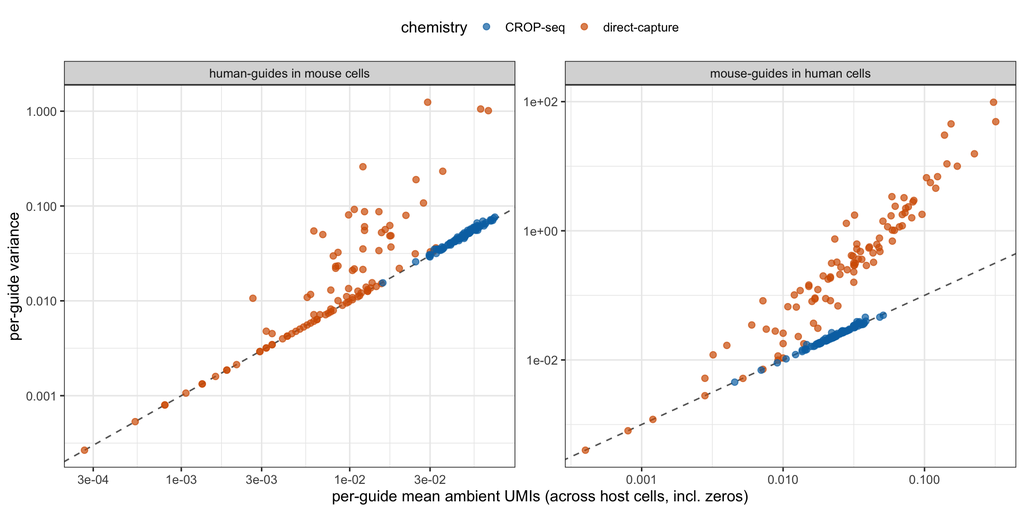

CLEANSER Fig-3B reproduction: per-guide variance vs mean of ground-truth ambient UMIs (0hr, GEX purity 0.90). Dashed line is var = mean (Poisson). Direct-capture mouse-in-human sits ABOVE the line; CROP-seq sits ON it.

```r
pgA <- rbind(
  transform(cleanser_perguide(dc, "mus_in_homo"), chem = "direct-capture", dir = "mouse-guides in human cells"),
  transform(cleanser_perguide(dc, "homo_in_mus"), chem = "direct-capture", dir = "human-guides in mouse cells"),
  transform(cleanser_perguide(cs, "mus_in_homo"), chem = "CROP-seq",       dir = "mouse-guides in human cells"),
  transform(cleanser_perguide(cs, "homo_in_mus"), chem = "CROP-seq",       dir = "human-guides in mouse cells"))
pgA <- pgA[is.finite(pgA$mean) & pgA$mean > 0, ]

ggplot(pgA, aes(mean, var, colour = chem)) +
  geom_abline(slope = 1, intercept = 0, linetype = "dashed", colour = "grey40") +
  geom_point(alpha = 0.7, size = 2) +
  facet_wrap(~dir, scales = "free") +
  scale_x_log10() + scale_y_log10() +
  scale_colour_manual(values = c("direct-capture" = "#D55E00", "CROP-seq" = "#0072B2")) +
  labs(x = "per-guide mean ambient UMIs (across host cells, incl. zeros)",
       y = "per-guide variance", colour = "chemistry") +
  theme(legend.position = "top")
```

# 4 Part 2 — The doublets are there

If the overdispersion were genuine “soup,” it would be spread smoothly across cells. Instead it is concentrated in a small tail of cells carrying a whole wrong-species cell’s worth of gRNA — co-encapsulated doublets.

```r
mask     <- amb_mask_of(dc)
cnt      <- dc$counts
amb_load <- Matrix::colSums(cnt * mask)                 # wrong-species UMIs / cell
tot_grna <- Matrix::colSums(cnt)
wrong_frac <- amb_load / pmax(tot_grna, 1)              # gRNA-channel doublet score

qs <- quantile(amb_load, c(0, .5, .9, .95, .99, .999, 1))
kable(t(round(qs)), caption = "Per-cell wrong-species gRNA UMI load (direct-capture 0hr)")
```

Per-cell wrong-species gRNA UMI load (direct-capture 0hr)

| 0% | 50% | 90% | 95% | 99% | 99.9% | 100% |
| --- | --- | --- | --- | --- | --- | --- |
| 0 | 0 | 3 | 4 | 30 | 259 | 1518 |

```r
load_med <- median(amb_load); load_q90 <- quantile(amb_load, .9)
load_q99 <- quantile(amb_load, .99); load_max <- max(amb_load)
```

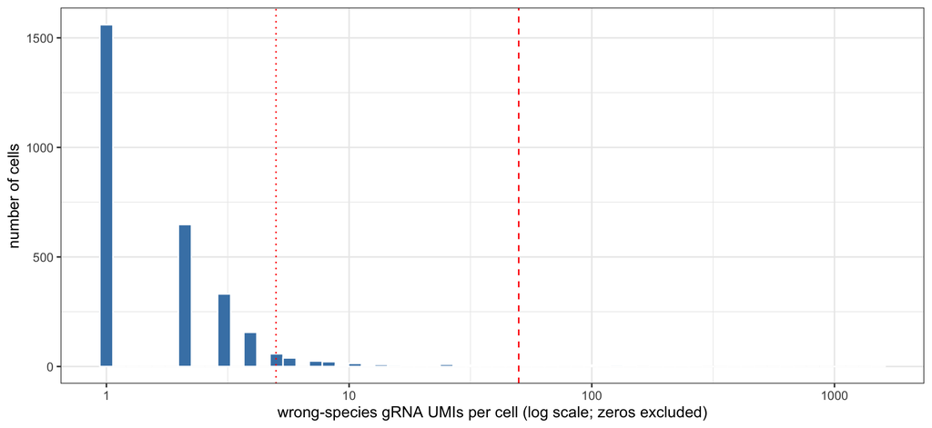

Per-cell wrong-species gRNA UMI load (direct-capture 0hr, GEX-pure cells, zeros omitted for the log axis). The bulk carries a few ambient UMIs; a right tail runs to >1000 — co-encapsulated wrong-species cells (doublets). Dotted = 5, dashed = 50.

```r
ggplot(data.frame(amb_load = amb_load[amb_load > 0]), aes(amb_load)) +
  geom_histogram(bins = 60, fill = "steelblue", colour = "white") +
  scale_x_log10() +
  geom_vline(xintercept = c(5, 50), linetype = c("dotted", "dashed"), colour = "red") +
  labs(x = "wrong-species gRNA UMIs per cell (log scale; zeros excluded)", y = "number of cells")
```

## 4.2 Example doublet cells: a whole wrong-species cell’s worth of gRNA

Cells with `wrong_frac` near 1 are essentially wrong-species cells: the guide that dominates their gRNA pool is from the *other* library. These are not ambient “soup” — they are doublets or mis-called cells.

```r
# top cells by wrong fraction (requiring a non-trivial gRNA count)
ord <- order(-wrong_frac)
ord <- ord[tot_grna[ord] >= 5][1:6]
# dominant guide per example cell
dominant <- vapply(ord, function(j) {
  col <- cnt[, j]; rownames(cnt)[which.max(col)]
}, character(1))
ex <- data.frame(
  cell_index   = ord,
  species_call = ifelse(dc$cell_homo[ord], "human", "mouse"),
  frac_homo_GEX = round(dc$frac_homo[ord], 3),
  total_grna_UMI = tot_grna[ord],
  wrong_species_UMI = amb_load[ord],
  wrong_frac = round(wrong_frac[ord], 3),
  dominant_guide = dominant,
  dominant_library = ifelse(guides$guide_type[match(dominant, guides$guide)] == "homo_guide",
                            "human", "mouse"))
kable(ex, row.names = FALSE,
      caption = "Example doublet cells: GEX calls one species, but the gRNA pool is dominated by a guide from the OTHER library (wrong_frac near 1).")
```

Example doublet cells: GEX calls one species, but the gRNA pool is dominated by a guide from the OTHER library (wrong_frac near 1).

| cell_index | species_call | frac_homo_GEX | total_grna_UMI | wrong_species_UMI | wrong_frac | dominant_guide | dominant_library |
| --- | --- | --- | --- | --- | --- | --- | --- |
| 821 | human | 0.994 | 121 | 121 | 1.000 | nt_176 | mouse |
| 3439 | human | 0.926 | 62 | 62 | 1.000 | nt_136 | mouse |
| 3976 | human | 0.947 | 1521 | 1518 | 0.998 | nt_179 | mouse |
| 174 | human | 0.921 | 216 | 213 | 0.986 | nt_126 | mouse |
| 2877 | human | 0.978 | 202 | 199 | 0.985 | nt_167 | mouse |
| 4326 | human | 0.963 | 133 | 131 | 0.985 | nt_191 | mouse |

Each row is a cell the GEX QC accepted as a confident single species, yet its gRNA channel is dominated by a guide from the opposite library — the signature of a co-encapsulated wrong-species cell.

## 4.3 Variance decomposition: the top 1% of cells own the overdispersion

We now quantify how concentrated the excess variance is. For the pooled ambient (every wrong-species entry, incl. zeros), compute the total sum-of-squares about the mean and the share contributed by cells in the top 1% by wrong-species load.

```r
mask_T <- as(mask, "TsparseMatrix"); jcell <- mask_T@j + 1L    # cell of each masked entry
vals_full <- (cnt * mask)[mask]
mu_all    <- mean(vals_full)
ss_total  <- sum((vals_full - mu_all)^2)

top1_cell  <- amb_load > quantile(amb_load, 0.99)
ss_top1    <- sum((vals_full[top1_cell[jcell]] - mu_all)^2)
top1_share <- 100 * ss_top1 / ss_total

# also the UMI share and how many cells that is
n_top1     <- sum(top1_cell)
umi_share  <- 100 * sum(amb_load[top1_cell]) / sum(amb_load)
data.frame(metric = c("cells in top 1% by wrong load",
                       "% of pooled ambient sum-of-squares from top 1% cells",
                       "% of all ambient UMIs carried by top 1% cells"),
           value = c(n_top1, round(top1_share, 1), round(umi_share, 1)))
```

| metric | value |
| --- | --- |
| cells in top 1% by wrong load | 63.0 |
| % of pooled ambient sum-of-squares from top 1% cells | 98.5 |
| % of all ambient UMIs carried by top 1% cells | 58.9 |

The **top 1% of cells (63 cells) account for 98.5% of the pooled ambient sum-of-squares** and carry 58.9% of all wrong-species UMIs. The “overdispersion” is not a property of the soup — it lives almost entirely in a handful of doublets.

We can watch the pooled var/mean melt as we peel off the top cells by load:

```r
sweep_tbl <- do.call(rbind, lapply(c(1.0, 0.999, 0.99, 0.95, 0.90), function(topq) {
  thr   <- quantile(amb_load, topq)
  keep  <- amb_load <= thr
  pv    <- pooled_vmr(dc, cell_subset = keep)
  data.frame(keep_below_quantile = topq, load_threshold = as.numeric(thr),
             cells_dropped = sum(!keep),
             pct_ambient_UMIs_dropped = round(100 * sum(amb_load[!keep]) / sum(amb_load), 1),
             pooled_vmr = round(pv$vmr, 2), pooled_max = pv$max)
}))
kable(sweep_tbl, caption = "Pooled ambient var/mean collapses as top-load cells are removed (direct-capture 0hr)")
```

Pooled ambient var/mean collapses as top-load cells are removed (direct-capture 0hr)

| keep_below_quantile | load_threshold | cells_dropped | pct_ambient_UMIs_dropped | pooled_vmr | pooled_max |
| --- | --- | --- | --- | --- | --- |
| 1.000 | 1518.000 | 0 | 0.0 | 54.00 | 484 |
| 0.999 | 258.984 | 7 | 23.8 | 14.01 | 103 |
| 0.990 | 30.380 | 63 | 58.9 | 2.01 | 26 |
| 0.950 | 4.000 | 280 | 72.0 | 1.02 | 3 |
| 0.900 | 3.000 | 436 | 75.9 | 1.02 | 3 |

Dropping merely the **top 1% of cells** by load takes the pooled var/mean from **54.00** to **2.01**, and dropping the top 5% takes it to **1.02** — i.e. essentially Poisson.

# 5 Part 3 — Clean the doublets and re-draw Figure 3B

The natural, transparent doublet filter is a **gRNA-channel purity cut**: drop any cell whose wrong-species fraction of total gRNA exceeds a cutoff. This is independent of the GEX QC and directly targets the co-encapsulation signature.

## 5.1 Fig 3B before vs after a gRNA-purity cut

```r
purity_tbl <- do.call(rbind, lapply(c(1.01, 0.50, 0.10, 0.05, 0.01), function(cut) {
  keep <- wrong_frac <= cut
  pg   <- cleanser_perguide(dc, "mus_in_homo", cell_subset = keep)
  pv   <- pooled_vmr(dc, cell_subset = keep)
  data.frame(gRNA_purity_filter = if (cut > 1) "keep ALL (GEX-pure only)"
                                  else sprintf("wrong_frac <= %.2f", cut),
             cells_kept = sum(keep), cells_dropped = sum(!keep),
             perguide_median_vmr = round(median(pg$vmr, na.rm = TRUE), 2),
             perguide_pct_above  = round(100 * mean(pg$var > pg$mean, na.rm = TRUE), 0),
             pooled_vmr = round(pv$vmr, 2), pooled_max = pv$max)
}))
kable(purity_tbl, caption = "Fig-3B dispersion under a gRNA-channel purity cut (direct-capture 0hr, mouse-in-human)")
```

Fig-3B dispersion under a gRNA-channel purity cut (direct-capture 0hr, mouse-in-human)

| gRNA_purity_filter | cells_kept | cells_dropped | perguide_median_vmr | perguide_pct_above | pooled_vmr | pooled_max |
| --- | --- | --- | --- | --- | --- | --- |
| keep ALL (GEX-pure only) | 6255 | 0 | 10.40 | 93 | 54.00 | 484 |
| wrong_frac <= 0.50 | 6154 | 101 | 2.17 | 71 | 16.35 | 148 |
| wrong_frac <= 0.10 | 5991 | 264 | 1.08 | 57 | 3.53 | 68 |
| wrong_frac <= 0.05 | 5919 | 336 | 1.06 | 55 | 3.22 | 68 |
| wrong_frac <= 0.01 | 5767 | 488 | 1.00 | 46 | 2.23 | 68 |

```r
clean_med_vmr <- purity_tbl$perguide_median_vmr[purity_tbl$gRNA_purity_filter == "wrong_frac <= 0.01"]
clean_pct_ab  <- purity_tbl$perguide_pct_above[purity_tbl$gRNA_purity_filter == "wrong_frac <= 0.01"]
clean_max     <- purity_tbl$pooled_max[purity_tbl$gRNA_purity_filter == "wrong_frac <= 0.01"]
raw_max       <- purity_tbl$pooled_max[1]
```

At a strict gRNA-purity cut (`wrong_frac <= 0.01`), the per-guide **median var/mean drops from 10.40 to 1.00**, only **46%** of guides remain above the line (a coin-flip, as expected under Poisson sampling noise), and the largest single ambient count falls from **484** to **68**. The overdispersion is gone.

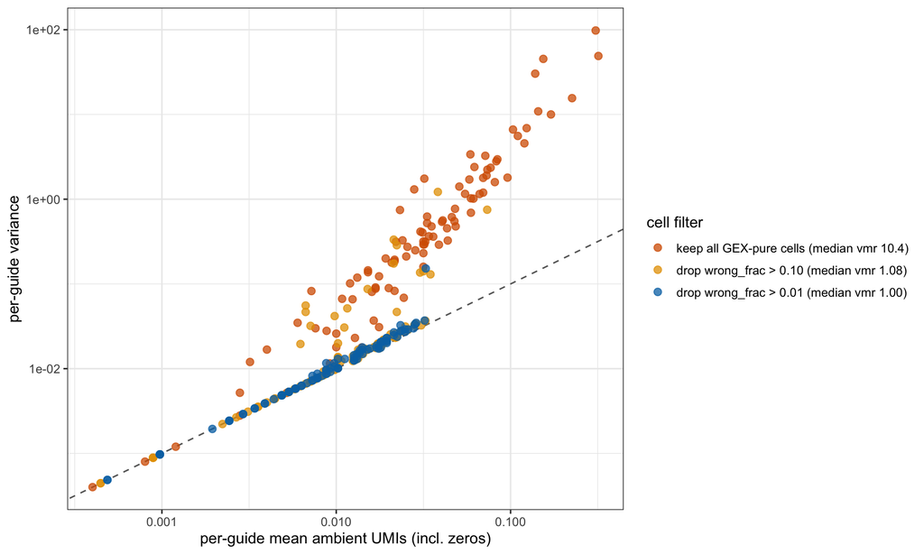

Direct-capture ambient overdispersion collapses to Poisson when gRNA-channel doublets are removed. Per-guide variance vs mean (mouse guides in human cells, 0hr). Dashed = var = mean. As the wrong-fraction cut tightens, the cloud pulls ONTO the Poisson line.

```r
rowsB <- lapply(c(1.01, 0.10, 0.01), function(cut) {
  keep <- wrong_frac <= cut
  pg   <- cleanser_perguide(dc, "mus_in_homo", cell_subset = keep)
  lab  <- if (cut > 1)
    sprintf("keep all GEX-pure cells (median vmr %.1f)", median(pg$vmr, na.rm = TRUE))
  else
    sprintf("drop wrong_frac > %.2f (median vmr %.2f)", cut, median(pg$vmr, na.rm = TRUE))
  transform(pg[is.finite(pg$mean) & pg$mean > 0, ], filter = lab)
})
pgB <- do.call(rbind, rowsB)
pgB$filter <- factor(pgB$filter, levels = vapply(rowsB, function(d) as.character(d$filter[1]), ""))

ggplot(pgB, aes(mean, var, colour = filter)) +
  geom_abline(slope = 1, intercept = 0, linetype = "dashed", colour = "grey40") +
  geom_point(alpha = 0.75, size = 2.4) +
  scale_x_log10() + scale_y_log10() +
  scale_colour_manual(values = c("#D55E00", "#E69F00", "#0072B2")) +
  labs(x = "per-guide mean ambient UMIs (incl. zeros)", y = "per-guide variance",
       colour = "cell filter")
```

## 5.2 After doublets: why a pooled NB fit is the wrong diagnostic

How Poisson is the de-doubleted ambient? The tempting shortcut — fit one Negative Binomial to the *pooled* de-doubleted counts by method of moments ($\mathrm{Var} = \mu + \mu^2/\theta$; size $\theta = \mu^2/(\mathrm{Var}-\mu)$, dispersion $\alpha = 1/\theta = (\mathrm{Var}-\mu)/\mu^2$; the Poisson limit is $\mathrm{Var}\to\mu$, i.e. $\theta\to\infty$ and $\alpha\to 0$) — is actually the **wrong diagnostic here**, and seeing why is the point. (The *right* tool is a bootstrap-calibrated goodness-of-fit test against $\mathrm{Poisson}(a_g d_c)$; we build it in §Part 4. This section only shows why the naive pooled fit must not be read as an answer.)

```r
nb_tbl <- do.call(rbind, lapply(c(1.01, 0.05, 0.01), function(cut) {
  keep <- wrong_frac <= cut
  vals <- (cnt * mask)[, keep, drop = FALSE][mask[, keep, drop = FALSE]]
  m <- mean(vals); v <- var(vals)
  theta_size <- if (v > m) m^2 / (v - m) else Inf   # NB size (MoM)
  alpha_disp <- if (v > m) (v - m) / m^2 else 0      # NB dispersion = 1/size
  data.frame(gRNA_purity = if (cut > 1) "keep ALL" else sprintf("wrong_frac <= %.2f", cut),
             cells = sum(keep), pooled_mean = round(m, 5), pooled_var = round(v, 5),
             NB_size_theta = round(theta_size, 4),
             NB_dispersion_alpha = signif(alpha_disp, 3))
}))
kable(nb_tbl, caption = "Method-of-moments NB fit to pooled ambient at increasing gRNA purity (direct-capture 0hr)")
```

Method-of-moments NB fit to pooled ambient at increasing gRNA purity (direct-capture 0hr)

| gRNA_purity | cells | pooled_mean | pooled_var | NB_size_theta | NB_dispersion_alpha |
| --- | --- | --- | --- | --- | --- |
| keep ALL | 6255 | 0.02550 | 1.37670 | 0.0005 | 2080 |
| wrong_frac <= 0.05 | 5919 | 0.01062 | 0.03416 | 0.0048 | 209 |
| wrong_frac <= 0.01 | 5767 | 0.00978 | 0.02182 | 0.0080 | 126 |

```r
theta_clean <- nb_tbl$NB_size_theta[nb_tbl$gRNA_purity == "wrong_frac <= 0.01"]
```

At the strict cut the pooled mean and variance are ~0.010 and ~0.022, so the **pooled** var/mean is $\approx 2.2$ — *not* Poisson at the pooled level — and the MoM fit returns a tiny size $\theta =$ **0.0080** (equivalently a large dispersion $\alpha = 1/\theta \approx$ **125**). This is exactly where the prior “$\alpha\approx 0.008$” figure went wrong: $0.008$ is the NB **size** $\theta$, which is *small precisely because the pool is overdispersed* — it is not a small dispersion and not Poisson.

Why is the pooled fit misleading? The pool mixes wrong-species guides of very different soup-shares $a_g$ and host cells of very different ambient depths $d_c$, and a mixture of Poissons with unequal means $\lambda_{gc}=a_g d_c$ always has pooled var/mean $>1$ (law of total variance) even when every entry is *exactly* Poisson. So a pooled NB fit conflates two things it cannot separate: **rank-1 mean-heterogeneity** (guide/cell mean spread, present under the null) and any genuine **entry-level dispersion** (the thing CLEANSER’s NB is meant to capture). The right question is not “is the pooled var/mean $>1$?” — it always is — but “is the pooled var/mean *larger than a rank-1 Poisson would itself produce*?”

A maximum-likelihood NB fit on the pooled counts (where the package is available) tells the same story — a small size, i.e. the pooled mean-heterogeneity again:

```r
if (requireNamespace("MASS", quietly = TRUE)) {
  keep <- wrong_frac <= 0.01
  vals <- (cnt * mask)[, keep, drop = FALSE][mask[, keep, drop = FALSE]]
  fit  <- tryCatch(suppressWarnings(MASS::fitdistr(vals, "negative binomial")),
                   error = function(e) NULL)
  if (!is.null(fit)) {
    cat(sprintf("MASS::fitdistr NB (wrong_frac<=0.01): size = %.4f, mu = %.5f\n",
                fit$estimate["size"], fit$estimate["mu"]))
    cat(sprintf("  -> pooled mean %.5f, var %.5f (var/mean = %.3f)\n",
                mean(vals), var(vals), var(vals) / mean(vals)))
  }
} else {
  cat("MASS not available; method-of-moments NB fit above is the reported estimate.\n")
}
```

```
MASS::fitdistr NB (wrong_frac<=0.01): size = 0.3881, mu = 0.00981
  -> pooled mean 0.00978, var 0.02182 (var/mean = 2.231)
```

## 5.3 The authors’ own GEX-purity knob does the same, more weakly

Tightening the GEX-purity threshold also strips doublets — but less efficiently, because a whole wrong-species cell can still pass a lenient GEX cut. Sweeping $p = 0.90 \to 0.95 \to 0.99$ walks the per-guide median var/mean down toward 1.

```r
gex_tbl <- do.call(rbind, lapply(c(0.90, 0.95, 0.99), function(pur) {
  op <- load_sample("mix0hr_DirectCapture", pur)
  pg <- cleanser_perguide(op, "mus_in_homo")
  pv <- pooled_vmr(op)
  data.frame(GEX_purity = pur, human_cells = sum(op$cell_homo),
             perguide_median_vmr = round(median(pg$vmr, na.rm = TRUE), 2),
             perguide_pct_above  = round(100 * mean(pg$var > pg$mean, na.rm = TRUE), 0),
             pooled_vmr = round(pv$vmr, 2), pooled_max = pv$max)
}))
kable(gex_tbl, caption = "GEX-purity knob (authors' own) also collapses the overdispersion, more weakly")
```

GEX-purity knob (authors’ own) also collapses the overdispersion, more weakly

| GEX_purity | human_cells | perguide_median_vmr | perguide_pct_above | pooled_vmr | pooled_max |
| --- | --- | --- | --- | --- | --- |
| 0.90 | 2499 | 10.40 | 93 | 54.00 | 484 |
| 0.95 | 2463 | 7.26 | 89 | 18.51 | 148 |
| 0.99 | 2277 | 1.05 | 54 | 2.98 | 58 |

At $p = 0.99$ the GEX knob alone brings the per-guide median var/mean to **1.05** and the max from **484** to **58** — the same direction as the gRNA-purity cut, confirming both knobs remove the same objects (doublets), and that the gRNA-channel cut is simply the more direct instrument.

## 5.4 Cross-check: the 72hr direct-capture sample replicates the pattern

```r
hr72 <- do.call(rbind, lapply(c("mix72hr_DirectCapture", "mix72hr_Cropseq"), function(s) {
  o    <- load_sample(s, 0.90)
  pg   <- cleanser_perguide(o, "mus_in_homo")
  mask2 <- amb_mask_of(o); cnt2 <- o$counts
  amb2 <- Matrix::colSums(cnt2 * mask2); wf2 <- amb2 / pmax(Matrix::colSums(cnt2), 1)
  pv_all   <- pooled_vmr(o)
  pv_clean <- pooled_vmr(o, cell_subset = wf2 <= 0.01)
  data.frame(sample = s, chemistry = o$chemistry,
             perguide_median_vmr = round(median(pg$vmr, na.rm = TRUE), 2),
             pooled_vmr_all = round(pv_all$vmr, 2), max_all = pv_all$max,
             pooled_vmr_dedoubleted = round(pv_clean$vmr, 2), max_dedoubleted = pv_clean$max)
}))
kable(hr72, caption = "72hr barnyard: same pattern — direct-capture ambient is doublet-inflated and collapses to Poisson under a gRNA-purity cut")
```

72hr barnyard: same pattern — direct-capture ambient is doublet-inflated and collapses to Poisson under a gRNA-purity cut

| sample | chemistry | perguide_median_vmr | pooled_vmr_all | max_all | pooled_vmr_dedoubleted | max_dedoubleted |
| --- | --- | --- | --- | --- | --- | --- |
| mix72hr_DirectCapture | direct-capture | 2.93 | 379.73 | 1339 | 1.09 | 7 |
| mix72hr_Cropseq | CROP-seq | 1.03 | 1.05 | 11 | 1.01 | 2 |

The 72hr direct-capture sample tells the same story: a pooled var/mean of **379.7** with a max of **1339** collapses to **1.09** (max **7**) once gRNA-channel doublets are removed, while CROP-seq is Poisson throughout.

# 6 Part 4 — Is the de-doubleted ambient actually Poisson? A bootstrap-calibrated test

Part 3 established what the *wrong* tool says. Here is the right one. We test the sharp hypothesis
$$H_0:\quad Y_{gc} \;\sim\; \mathrm{Poisson}(\lambda_{gc}),\qquad
\lambda_{gc} \;=\; a_g\,d_c \;=\; \frac{R_g\,C_c}{T},$$
i.e. the de-doubleted ground-truth ambient count of guide $g$ in host cell $c$ is Poisson with a **rank-1 mean** — guide soup-share $a_g=R_g/T$ times cell soup-exposure $C_c$ ($R_g$, $C_c$ are the guide/cell margins of the de-doubleted submatrix, $T$ the grand total). This is exactly fishash’s / geomux’s ambient null. The obstacle to testing it is that the rates are tiny (per-entry means $\sim 0.005$–$0.3$, counts almost all 0/1), so asymptotic $\chi^2$ / dispersion references are unreliable. We therefore **calibrate every statistic by parametric bootstrap**: simulate $Y^{(b)}\sim\mathrm{Poisson}(\hat\lambda)$, **re-fit the rank-1 mean each rep**, and read the observed statistic against its own Poisson null band. Three statistics, one mask direction (mouse-library guides in human cells — the overdispersed one), plus controls that prove the test discriminates.

**Note**

The bootstrap runs live at render time with `B = 200` and `set.seed(1)`, so every band below is reproduced from the raw counts. On this cohort the whole section (4 conditions + power) takes well under a minute.

```r
set.seed(1L)
B_GOF          <- 200L    # bootstrap reps (matches the reported bands)
NBINS          <- 10L     # matched-mean lambda bins
LAM_FLOOR_BIN  <- 0.02    # floor for the matched-mean binning (informative entries)
LAM_FLOOR_PHI  <- 0.01    # floor for the "informative-entry" Pearson phi
KMAX           <- 4L      # count histogram last bin is >=4

# Build the wrong-species-guide x host-cell submatrix Y (dense, small), in a
# direction, after an optional gRNA-purity (doublet) cut wf_cut. Inf keeps all.
build_Y <- function(obj, direction = c("mus_in_homo", "homo_in_mus"), wf_cut = 0.01) {
  direction <- match.arg(direction)
  cnt  <- obj$counts
  tot  <- Matrix::colSums(cnt)
  wm   <- outer(obj$guide_homo, obj$cell_homo, function(g, c) g != c)
  amb  <- Matrix::colSums(cnt * as(Matrix(wm, sparse = TRUE), "lgCMatrix"))
  wf   <- amb / pmax(tot, 1)
  if (direction == "mus_in_homo") { gsel <- !obj$guide_homo; csel <-  obj$cell_homo }
  else                            { gsel <-  obj$guide_homo; csel <- !obj$cell_homo }
  csel <- csel & (wf <= wf_cut)
  Y <- as.matrix(cnt[gsel, csel, drop = FALSE]); storage.mode(Y) <- "double"
  n_drop <- sum((if (direction == "mus_in_homo") obj$cell_homo else !obj$cell_homo) & (wf > wf_cut))
  list(Y = Y, n_guides = nrow(Y), n_cells = ncol(Y), n_dropped = n_drop)
}

# Fit rank-1 Poisson mean lambda_hat = R_g C_c / T and compute all GOF statistics
# for a count matrix Y. bin_breaks fixed from the observed fit so per-bin var/mean
# is comparable across bootstrap reps.
fit_stats <- function(Y, bin_breaks = NULL) {
  R <- rowSums(Y); C <- colSums(Y); Tg <- sum(Y)
  lam <- outer(R, C) / Tg
  yv <- as.vector(Y); lv <- as.vector(lam)
  # (a) count histogram O_k vs Poisson E_k for k = 0,1,2,3,>=4
  Ok <- c(sum(yv == 0), sum(yv == 1), sum(yv == 2), sum(yv == 3), sum(yv >= 4))
  p0 <- dpois(0, lv); p1 <- dpois(1, lv); p2 <- dpois(2, lv); p3 <- dpois(3, lv)
  Ek <- c(sum(p0), sum(p1), sum(p2), sum(p3), sum(1 - (p0 + p1 + p2 + p3)))
  # (b) Pearson dispersion phi = mean((y-lam)^2/lam), over lam>0 and over lam>=floor
  pos <- lv > 0
  phi_all   <- mean((yv[pos] - lv[pos])^2 / lv[pos])
  keepf     <- lv >= LAM_FLOOR_PHI
  phi_floor <- if (sum(keepf) > 0) mean((yv[keepf] - lv[keepf])^2 / lv[keepf]) else NA_real_
  # (c) matched-mean var/mean by lambda bin (fixed quantile breaks over lam>=floor)
  bs <- lv >= LAM_FLOOR_BIN; yb <- yv[bs]; lb <- lv[bs]
  if (is.null(bin_breaks)) {
    qs <- quantile(lb, probs = seq(0, 1, length.out = NBINS + 1L), na.rm = TRUE)
    qs[1] <- -Inf; qs[length(qs)] <- Inf; bin_breaks <- unique(qs)
  }
  g <- cut(lb, breaks = bin_breaks, include.lowest = TRUE, labels = FALSE)
  bt <- data.frame(bin = seq_len(length(bin_breaks) - 1L),
                   n = NA_real_, lam_mean = NA_real_, y_mean = NA_real_, vmr = NA_real_)
  for (bb in bt$bin) {
    ix <- which(g == bb)
    if (length(ix) >= 2) {
      bt$n[bb] <- length(ix); bt$lam_mean[bb] <- mean(lb[ix])
      bt$y_mean[bb] <- mean(yb[ix]); bt$vmr[bb] <- var(yb[ix]) / bt$y_mean[bb]
    }
  }
  list(Ok = Ok, Ek = Ek, ratio = Ok / Ek, phi_all = phi_all, phi_floor = phi_floor,
       n_phi_floor = sum(keepf), bin = bt, bin_breaks = bin_breaks,
       pooled_mean = mean(yv), pooled_var = var(yv), pooled_vmr = var(yv) / mean(yv),
       n_entries = length(yv), n_nz = sum(yv > 0), maxct = max(yv))
}

# Parametric bootstrap: simulate Poisson(lambda_hat), REFIT rank-1 mean, recompute.
boot_null <- function(Y, obs_breaks, B = B_GOF) {
  R <- rowSums(Y); C <- colSums(Y); Tg <- sum(Y)
  lamv <- as.vector(outer(R, C) / Tg); nG <- nrow(Y); nC <- ncol(Y)
  nbin <- length(obs_breaks) - 1L
  out <- list(phi_all = numeric(B), phi_floor = numeric(B), pooled_vmr = numeric(B),
              ratio = matrix(NA_real_, B, 5), vmr_bin = matrix(NA_real_, B, nbin))
  for (b in seq_len(B)) {
    yb <- rpois(nG * nC, lamv); dim(yb) <- c(nG, nC)
    st <- fit_stats(yb, bin_breaks = obs_breaks)
    out$phi_all[b] <- st$phi_all; out$phi_floor[b] <- st$phi_floor
    out$pooled_vmr[b] <- st$pooled_vmr; out$ratio[b, ] <- st$ratio; out$vmr_bin[b, ] <- st$bin$vmr
  }
  out
}

pct     <- function(x) quantile(x, c(.025, .5, .975), na.rm = TRUE)
inside  <- function(o, x) { q <- pct(x); o >= q[1] & o <= q[3] }
verdict <- function(o, x) { q <- pct(x); if (o > q[3]) "ABOVE (overdisp)" else if (o < q[1]) "BELOW (underdisp)" else "INSIDE (Poisson-OK)" }
pboot_upper <- function(o, x) (1 + sum(x >= o)) / (1 + length(x))

# run one condition end-to-end; returns obs + null for tables/plots
run_condition <- function(obj, direction, wf_cut, B = B_GOF) {
  bd  <- build_Y(obj, direction, wf_cut)
  obs <- fit_stats(bd$Y)
  nb  <- boot_null(bd$Y, obs$bin_breaks, B = B)
  list(obs = obs, null = nb, bd = bd)
}
```

## 6.1 The main test: de-doubleted direct-capture is inside the Poisson null band

We fit $\hat\lambda_{gc}=R_gC_c/T$ on the de-doubleted (`wrong_frac <= 0.01`) mouse-in-human submatrix, then bootstrap the Poisson null.

```r
resA <- run_condition(dc, "mus_in_homo", wf_cut = 0.01)   # de-doubleted (main)
resB <- run_condition(dc, "mus_in_homo", wf_cut = Inf)    # RAW (positive control)
resD <- run_condition(cs, "mus_in_homo", wf_cut = 0.01)   # CROP-seq (comparison)

# Poisson-sim calibration control: one Poisson draw from the de-doubleted fit,
# treated AS IF it were data. Must PASS (the test must not flag its own null).
{
  Ym <- resA$bd$Y; Rm <- rowSums(Ym); Cm <- colSums(Ym); Tm <- sum(Ym)
  lam_sim <- as.vector(outer(Rm, Cm) / Tm)
  Ysim <- matrix(rpois(length(lam_sim), lam_sim), nrow(Ym), ncol(Ym))
  obsC <- fit_stats(Ysim); nbC <- boot_null(Ysim, obsC$bin_breaks, B = B_GOF)
  resC <- list(obs = obsC, null = nbC)
}

band <- function(res, which = "phi_floor") {
  o <- res$obs[[which]]; q <- pct(res$null[[which]])
  sprintf("%.3f  [%.3f, %.3f]", o, q[1], q[3])
}
```

```r
gof_tab <- data.frame(
  statistic = c("Pearson phi (lambda_hat >= 0.01)",
                "Pearson phi (all lambda_hat > 0)",
                "pooled var/mean",
                "bootstrap p (upper) for phi>=floor"),
  observed = c(fmt(resA$obs$phi_floor, 3), fmt(resA$obs$phi_all, 3),
               fmt(resA$obs$pooled_vmr, 3),
               fmt(pboot_upper(resA$obs$phi_floor, resA$null$phi_floor), 3)),
  poisson_null_95_band = c(
    sprintf("[%.3f, %.3f]", pct(resA$null$phi_floor)[1], pct(resA$null$phi_floor)[3]),
    sprintf("[%.3f, %.3f]", pct(resA$null$phi_all)[1],   pct(resA$null$phi_all)[3]),
    sprintf("[%.3f, %.3f]", pct(resA$null$pooled_vmr)[1], pct(resA$null$pooled_vmr)[3]),
    "-"),
  verdict = c(verdict(resA$obs$phi_floor, resA$null$phi_floor),
              verdict(resA$obs$phi_all, resA$null$phi_all),
              verdict(resA$obs$pooled_vmr, resA$null$pooled_vmr), "-"))
kable(gof_tab, caption = "De-doubleted direct-capture (mouse-in-human, wrong_frac<=0.01): observed GOF statistics vs the parametric-Poisson bootstrap null band (B=200).")
```

De-doubleted direct-capture (mouse-in-human, wrong_frac<=0.01): observed GOF statistics vs the parametric-Poisson bootstrap null band (B=200).

| statistic | observed | poisson_null_95_band | verdict |
| --- | --- | --- | --- |
| Pearson phi (lambda_hat >= 0.01) | 0.993 | [0.956, 1.018] | INSIDE (Poisson-OK) |
| Pearson phi (all lambda_hat > 0) | 1.015 | [0.943, 1.033] | INSIDE (Poisson-OK) |
| pooled var/mean | 1.210 | [1.093, 1.148] | ABOVE (overdisp) |
| bootstrap p (upper) for phi>=floor | 0.254 | - | - |

```r
# stash for inline use
phiA      <- resA$obs$phi_floor
phiA_lo   <- pct(resA$null$phi_floor)[1]; phiA_hi <- pct(resA$null$phi_floor)[3]
pA        <- pboot_upper(resA$obs$phi_floor, resA$null$phi_floor)
poolA     <- resA$obs$pooled_vmr
poolA_null<- pct(resA$null$pooled_vmr)[2]
```

The observed Pearson dispersion over informative entries is $\phi = 0.993$, sitting **inside** the Poisson null band $[0.956, 1.018]$ with bootstrap $p \approx 0.25$ — no evidence against Poisson. The **pooled** var/mean is $1.21$, which does read “above” its band — **but the Poisson null itself reproduces a pooled var/mean of $\approx 1.12$** (that is the rank-1 mean-heterogeneity of Part 3), so only a sliver of the pooled number is unexplained. We localize that sliver below.

```r
klab <- c("0", "1", "2", "3", ">=4")
oe <- data.frame(
  k = klab, O_k = round(resA$obs$Ok), E_k = round(resA$obs$Ek, 1),
  O_over_E = fmt(resA$obs$ratio, 3),
  null_band = vapply(1:5, function(k) {
    q <- pct(resA$null$ratio[, k]); sprintf("[%.3f, %.3f]", q[1], q[3]) }, ""),
  verdict = vapply(1:5, function(k) verdict(resA$obs$ratio[k], resA$null$ratio[, k]), ""))
kable(oe, caption = "Count-histogram goodness-of-fit: observed O_k, Poisson-expected E_k, ratio O/E, and the bootstrap null band per count k (de-doubleted direct-capture).")
```

Count-histogram goodness-of-fit: observed O_k, Poisson-expected E_k, ratio O/E, and the bootstrap null band per count k (de-doubleted direct-capture).

| k | O_k | E_k | O_over_E | null_band | verdict |
| --- | --- | --- | --- | --- | --- |
| 0 | 203230 | 203223.8 | 1.000 | [1.000, 1.000] | ABOVE (overdisp) |
| 1 | 2059 | 2059.9 | 1.000 | [1.003, 1.033] | BELOW (underdisp) |
| 2 | 99 | 104.3 | 0.950 | [0.761, 1.019] | INSIDE (Poisson-OK) |
| 3 | 10 | 10.3 | 0.974 | [0.387, 1.433] | INSIDE (Poisson-OK) |
| >=4 | 2 | 1.9 | 1.076 | [0.000, 2.087] | INSIDE (Poisson-OK) |

## 6.2 The two headline figures

The **matched-mean var/mean by $\lambda$ bin** is the cleanest picture: under Poisson, var/mean $\approx 1$ in *every* bin, and the bootstrap band shows how much scatter that entails at these rates. De-doubleted direct-capture hugs 1 across the informative range; the raw (pre-cut) ambient explodes.

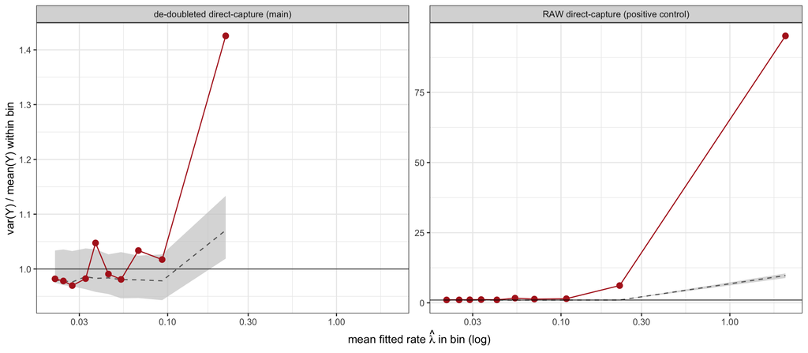

Matched-mean var/mean per lambda_hat bin, observed vs the parametric-Poisson bootstrap null band (B=200). Under Poisson, var/mean ~ 1 in every bin. LEFT: de-doubleted direct-capture hugs 1 across the informative range (only the top lambda bin — the cut boundary — pokes just above). RIGHT: raw (pre-cut) ambient trips the test hard, reaching var/mean ~ 95 in the top bin. Note the free y-axes.

```r
vmr_df <- function(res, cond) {
  q <- t(apply(res$null$vmr_bin, 2, function(x) quantile(x, c(.025, .5, .975), na.rm = TRUE)))
  d <- data.frame(lam = res$obs$bin$lam_mean, obs = res$obs$bin$vmr,
                  lo = q[, 1], mid = q[, 2], hi = q[, 3], cond = cond)
  d[is.finite(d$obs) & is.finite(d$lam), ]
}
pdV <- rbind(vmr_df(resA, "de-doubleted direct-capture (main)"),
             vmr_df(resB, "RAW direct-capture (positive control)"))
pdV$cond <- factor(pdV$cond, levels = unique(pdV$cond))
ggplot(pdV, aes(lam)) +
  geom_ribbon(aes(ymin = lo, ymax = hi), fill = "grey80", alpha = 0.7) +
  geom_line(aes(y = mid), colour = "grey40", linetype = "dashed") +
  geom_point(aes(y = obs), colour = "firebrick", size = 2.4) +
  geom_line(aes(y = obs), colour = "firebrick") +
  geom_hline(yintercept = 1, colour = "black", linewidth = 0.3) +
  facet_wrap(~cond, scales = "free_y") + scale_x_log10() +
  labs(x = expression("mean fitted rate " * hat(lambda) * " in bin (log)"),
       y = "var(Y) / mean(Y) within bin") +
  theme_bw(base_size = 11)
```

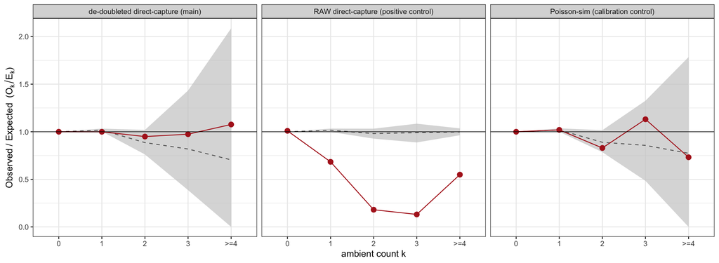

```r
oe_df <- function(res, cond) {
  q <- t(apply(res$null$ratio, 2, function(x) quantile(x, c(.025, .5, .975), na.rm = TRUE)))
  data.frame(k = factor(klab, levels = klab), obs = res$obs$ratio,
             lo = q[, 1], mid = q[, 2], hi = q[, 3], cond = cond)
}
pdOE <- rbind(oe_df(resA, "de-doubleted direct-capture (main)"),
              oe_df(resB, "RAW direct-capture (positive control)"),
              oe_df(resC, "Poisson-sim (calibration control)"))
pdOE$cond <- factor(pdOE$cond, levels = unique(pdOE$cond))
ggplot(pdOE, aes(k)) +
  geom_ribbon(aes(ymin = lo, ymax = hi, group = 1), fill = "grey80", alpha = 0.7) +
  geom_line(aes(y = mid, group = 1), colour = "grey40", linetype = "dashed") +
  geom_point(aes(y = obs), colour = "firebrick", size = 2.6) +
  geom_line(aes(y = obs, group = 1), colour = "firebrick") +
  geom_hline(yintercept = 1, colour = "black", linewidth = 0.3) +
  facet_wrap(~cond, nrow = 1) +
  labs(x = "ambient count k", y = expression("Observed / Expected  (" * O[k] / E[k] * ")")) +
  theme_bw(base_size = 11)
```

## 6.3 The pooled excess is a few cut-boundary doublet entries, not soup overdispersion

The observed pooled var/mean ($\approx 1.21$) sits just above what the Poisson null reproduces ($\approx 1.12$). That residual is not smooth overdispersion: it is **1–5 individual entries sitting just under the doublet cut** (a large ambient count in a host cell whose wrong-fraction is a hair below $0.01$). We show this two ways. First, the single largest de-doubleted ambient counts:

```r
YA <- resA$bd$Y
# recover, for each large entry, the host cell's wrong-fraction (proximity to the cut)
tot_all  <- Matrix::colSums(dc$counts)
amb_all  <- Matrix::colSums(dc$counts * amb_mask_of(dc))
wf_all   <- amb_all / pmax(tot_all, 1)
keepA    <- (dc$cell_homo) & (wf_all <= 0.01)          # human cells kept in resA
wf_kept  <- wf_all[keepA]
top_entries <- which(YA >= 6, arr.ind = TRUE)
if (nrow(top_entries) > 0) {
  od <- order(-YA[top_entries])
  top_entries <- top_entries[od, , drop = FALSE]
  ot <- data.frame(
    ambient_count = YA[top_entries],
    host_cell_wrong_frac = round(wf_kept[top_entries[, "col"]], 4),
    dist_below_cut = round(0.01 - wf_kept[top_entries[, "col"]], 4))
  kable(head(ot, 8), row.names = FALSE,
        caption = "Largest de-doubleted ambient counts and their host cell's wrong-species fraction. The heaviest entries live at wrong_frac just under the 0.01 cut — near-miss doublets, not soup.")
}
```

Largest de-doubleted ambient counts and their host cell’s wrong-species fraction. The heaviest entries live at wrong_frac just under the 0.01 cut — near-miss doublets, not soup.

| ambient_count | host_cell_wrong_frac | dist_below_cut |
| --- | --- | --- |
| 16 | 0.0073 | 0.0027 |

```r
cut_tab <- do.call(rbind, lapply(c("mus_in_homo", "homo_in_mus"), function(dir) {
  do.call(rbind, lapply(c(0.020, 0.010, 0.005, 0.0025), function(cut) {
    bd  <- build_Y(dc, dir, wf_cut = cut)
    st  <- fit_stats(bd$Y)
    data.frame(direction = if (dir == "mus_in_homo") "mouse-in-human" else "human-in-mouse",
               wrong_frac_cut = cut, cells = bd$n_cells,
               phi_floor = round(st$phi_floor, 3),
               pooled_vmr = round(st$pooled_vmr, 3), max_count = st$maxct)
  }))
}))
kable(cut_tab, row.names = FALSE,
      caption = "Both directions collapse to the Poisson floor as the doublet cut tightens (direct-capture 0hr). At wrong_frac<=0.005 the pooled var/mean is ~1.05-1.08 and phi~0.99.")
```

| direction | wrong_frac_cut | cells | phi_floor | pooled_vmr | max_count |
| --- | --- | --- | --- | --- | --- |
| mouse-in-human | 0.0200 | 2103 | 0.999 | 1.312 | 16 |
| mouse-in-human | 0.0100 | 2054 | 0.993 | 1.210 | 16 |
| mouse-in-human | 0.0050 | 2006 | 0.983 | 1.111 | 4 |
| mouse-in-human | 0.0025 | 1860 | 0.979 | 1.122 | 4 |
| human-in-mouse | 0.0200 | 3730 | 1.059 | 3.012 | 68 |
| human-in-mouse | 0.0100 | 3713 | 1.054 | 2.936 | 68 |
| human-in-mouse | 0.0050 | 3697 | 0.990 | 1.081 | 10 |
| human-in-mouse | 0.0025 | 3637 | 0.988 | 1.062 | 10 |

## 6.4 Controls: the test discriminates

A goodness-of-fit test is only worth its verdict if it *fails* when it should. It does:

```r
ctrl <- data.frame(
  condition = c("RAW direct-capture (pre-cut) [must FAIL]",
                "Poisson simulation as data [must PASS]",
                "de-doubleted CROP-seq [must PASS, cleanly]"),
  phi_floor = c(fmt(resB$obs$phi_floor, 3), fmt(resC$obs$phi_floor, 3), fmt(resD$obs$phi_floor, 3)),
  poisson_null_band = c(
    sprintf("[%.3f, %.3f]", pct(resB$null$phi_floor)[1], pct(resB$null$phi_floor)[3]),
    sprintf("[%.3f, %.3f]", pct(resC$null$phi_floor)[1], pct(resC$null$phi_floor)[3]),
    sprintf("[%.3f, %.3f]", pct(resD$null$phi_floor)[1], pct(resD$null$phi_floor)[3])),
  pooled_vmr = c(fmt(resB$obs$pooled_vmr, 2), fmt(resC$obs$pooled_vmr, 3), fmt(resD$obs$pooled_vmr, 3)),
  verdict = c(verdict(resB$obs$phi_floor, resB$null$phi_floor),
              verdict(resC$obs$phi_floor, resC$null$phi_floor),
              verdict(resD$obs$phi_floor, resD$null$phi_floor)))
kable(ctrl, caption = "Controls. The raw ambient trips the test hard (phi ~ 2.84, pooled var/mean ~ 71); a Poisson simulation passes; de-doubleted CROP-seq is cleanly Poisson (pooled var/mean ~ 1.005).")
```

Controls. The raw ambient trips the test hard (phi ~ 2.84, pooled var/mean ~ 71); a Poisson simulation passes; de-doubleted CROP-seq is cleanly Poisson (pooled var/mean ~ 1.005).

| condition | phi_floor | poisson_null_band | pooled_vmr | verdict |
| --- | --- | --- | --- | --- |
| RAW direct-capture (pre-cut) [must FAIL] | 2.843 | [0.953, 1.016] | 71.16 | ABOVE (overdisp) |
| Poisson simulation as data [must PASS] | 0.998 | [0.956, 1.014] | 1.127 | INSIDE (Poisson-OK) |
| de-doubleted CROP-seq [must PASS, cleanly] | 1.009 | [0.952, 1.021] | 1.005 | INSIDE (Poisson-OK) |

```r
phiB <- resB$obs$phi_floor; poolB <- resB$obs$pooled_vmr; poolD <- resD$obs$pooled_vmr
```

The **raw** (pre-doublet-cut) ambient trips the test hard — $\phi = 2.84$ far above its null band, pooled var/mean $\approx 71$ — confirming the doublets are exactly what the test is built to catch, and that the de-doubleted PASS is not the test being blind. A **Poisson simulation** treated as data passes (the test does not flag its own null model), and **de-doubleted CROP-seq** is cleanly Poisson (pooled var/mean $\approx 1.005$) — the chemistry that never had the doublet problem.

## 6.5 Power: what this test can and cannot rule out (honest bounds)

At these tiny ambient rates the test is not omnipotent. We quantify its reach by simulating NB alternatives $\mathrm{NB}(\mu=\hat\lambda,\ \text{size}=1/\alpha)$ (so $\mathrm{Var}=\mu+\alpha\mu^2$) over a grid of dispersion $\alpha$ and reporting the fraction of reps whose $\phi$ exceeds the Poisson $97.5\%$ band.

```r
YA  <- resA$bd$Y
Rp  <- rowSums(YA); Cp <- colSums(YA); Tp <- sum(YA)
lamv <- as.vector(outer(Rp, Cp) / Tp)
phi_hi <- quantile(resA$null$phi_floor, 0.975, na.rm = TRUE)
alphas <- c(0.1, 0.25, 0.5, 1, 2); npow <- 100L
pow_tab <- do.call(rbind, lapply(alphas, function(al) {
  hit <- 0L
  for (r in seq_len(npow)) {
    yb <- rnbinom(length(lamv), size = 1 / al, mu = lamv); dim(yb) <- dim(YA)
    st <- fit_stats(yb, bin_breaks = resA$obs$bin_breaks)
    if (!is.na(st$phi_floor) && st$phi_floor > phi_hi) hit <- hit + 1L
  }
  data.frame(NB_dispersion_alpha = al, NB_size = round(1 / al, 2),
             power_at_5pct = round(hit / npow, 2))
}))
kable(pow_tab, row.names = FALSE,
      caption = "Power to detect NB overdispersion at the de-doubleted rates (detect = observed phi above the Poisson 97.5% band). The test rules out alpha >~ 1 but is blind to a mild alpha <~ 0.25.")
```

| NB_dispersion_alpha | NB_size | power_at_5pct |
| --- | --- | --- |
| 0.10 | 10.0 | 0.04 |
| 0.25 | 4.0 | 0.06 |
| 0.50 | 2.0 | 0.18 |
| 1.00 | 1.0 | 0.58 |
| 2.00 | 0.5 | 1.00 |

## 6.6 Bottom line (Part 4)

# 7 Conclusion

```r
data.frame(
  quantity = c(
    "Fig-3B direct-capture per-guide median var/mean (as published)",
    "Fig-3B CROP-seq per-guide median var/mean (as published)",
    "Direct-capture pooled ambient var/mean (all cells)",
    "Top 1% of cells' share of pooled ambient sum-of-squares",
    "De-doubleted (wrong_frac<=0.01) per-guide median var/mean",
    "De-doubleted pooled ambient var/mean (mouse-in-human)",
    "De-doubleted Pearson phi (informative entries; Poisson null [0.956, 1.018])"),
  value = c(fmt(dc_med_vmr), fmt(cs_med_vmr), fmt(dc_pool_vmr, 1),
            paste0(fmt(top1_share, 1), "%"), fmt(clean_med_vmr),
            fmt(poolA, 2), fmt(phiA, 3)))
```

| quantity | value |
| --- | --- |
| Fig-3B direct-capture per-guide median var/mean (as published) | 10.40 |
| Fig-3B CROP-seq per-guide median var/mean (as published) | 1.01 |
| Direct-capture pooled ambient var/mean (all cells) | 71.1 |
| Top 1% of cells’ share of pooled ambient sum-of-squares | 98.5% |
| De-doubleted (wrong_frac<=0.01) per-guide median var/mean | 1.00 |
| De-doubleted pooled ambient var/mean (mouse-in-human) | 1.21 |
| De-doubleted Pearson phi (informative entries; Poisson null [0.956, 1.018]) | 0.993 |

Stated plainly:

*Every figure and every number above is computed at render time from the raw barnyard MatrixMarket counts under `external/repro_work/`. Re-run with* `quarto render doublet_overdispersion.qmd --to html`.